# 07_3.10数据透视表

```python
%%HTML
<style type='text/css'>
    *{
        # background-color:#E3EDCD;
        # background-color:black;
        # color:white;

    }
    h1{
        color:#1976d2;
    }
    h2{
        color:#f57c00;
    }
    h3{
        color:#ba37ff;
    }
    h4{
        color:green;
    }
    table{
        border:1px solid black !important;
        border-collapse:collapse !important;
    }
    th{
        background-color:blueviolet !important;
        text-align:center;
        color:white;
    }
    th,td{
        border:0.1px solid black !important;
        transition:0.2s all liner;

    }
    td:hover{
        transform:scale(1.1);
        background-color:orange;
        color:blueviolet;
    }
    .raw{
        white-space:pre;
        color:green;
    }
    #imp{
        color:red;
    }
    #ct{
        text-align:center;
    }
</style>
```

## 3.10 数据透视表

我们已经介绍过 GroupBy 抽象类是如何探索数据集内部的关联性的 了。数据透视表（pivot table）是一种类似的操作方法，常见于 Excel 与 类似的表格应用中。数据透视表将每一列数据作为输入，输出将数据不 断细分成多个维度累计信息的二维数据表。人们有时容易弄混数据透视 表与 GroupBy，但我觉得数据透视表更像是一种多维的 GroupBy 累计 操作。也就是说，虽然你也可以分割 - 应用 - 组合，但是分割与组合不 是发生在一维索引上，而是在二维网格上（行列同时分组）。

### 3.10.1 演示数据透视表

这一节的示例将采用泰坦尼克号的乘客信息数据库来演示，可以在 Seaborn 程序库（详情请参见 4.16 节）获取：

```python
import numpy as np
import pandas as pd
import seaborn as sns
titanic =  sns.load_dataset('titanic')
titanic.head()
```

|  | survived | pclass | sex | age | sibsp | parch | fare | embarked | class | who | adult_male | deck | embark_town | alive | alone |
| --- | --- | --- | --- | --- | --- | --- | --- | --- | --- | --- | --- | --- | --- | --- | --- |
| 0 | 0 | 3 | male | 22.0 | 1 | 0 | 7.2500 | S | Third | man | True | NaN | Southampton | no | False |
| 1 | 1 | 1 | female | 38.0 | 1 | 0 | 71.2833 | C | First | woman | False | C | Cherbourg | yes | False |
| 2 | 1 | 3 | female | 26.0 | 0 | 0 | 7.9250 | S | Third | woman | False | NaN | Southampton | yes | True |
| 3 | 1 | 1 | female | 35.0 | 1 | 0 | 53.1000 | S | First | woman | False | C | Southampton | yes | False |
| 4 | 0 | 3 | male | 35.0 | 0 | 0 | 8.0500 | S | Third | man | True | NaN | Southampton | no | True |

这份数据包含了惨遭厄运的每位乘客的大量信息，包括性别 （gender）、年龄（age）、船舱等级（class）和船票价格（fare paid） 等。

### 3.10.2 手工制作数据透视表

在研究这些数据之前，先将它们按照性别、最终生还状态或其他组合属 性进行分组。如果你看过前面的章节，你可能会用 GroupBy 来实现， 例如这样统计不同性别乘客的生还率：

```python
titanic.groupby('sex')[['survived']].mean()
```

| sex | survived |
| --- | --- |
| female | 0.742038 |
| male | 0.188908 |

这组数据会立刻给我们一个直观感受：总体来说，有四分之三的女性被 救，但只有五分之一的男性被救！

这组数据很有用，但是我们可能还想进一步探索，同时观察不同性别与 船舱等级的生还情况。根据 GroupBy 的操作流程，我们也许能够实现 想要的结果：将船舱等级（'class'）与性别（'sex'）分组，然后选 择生还状态（'survived'）列，应用均值（'mean'）累计函数，再将 各组结果组合，最后通过行索引转列索引操作将最里层的行索引转换成 列索引，形成二维数组。代码如下所示：

```python
titanic.groupby(['sex','class'],observed=True)['survived'].\
aggregate('mean').unstack()
```

| class sex | First | Second | Third |
| --- | --- | --- | --- |
| female | 0.968085 | 0.921053 | 0.500000 |
| male | 0.368852 | 0.157407 | 0.135447 |

虽然这样就可以更清晰地观察乘客性别、船舱等级对其是否生还的影 响，但是代码看上去有点复杂。尽管这个管道命令的每一步都是前面介 绍过的，但是要理解这个长长的语句可不是那么容易的事。由于二维的 GroupBy 应用场景非常普遍，因此 Pandas 提供了一个快捷方式 pivot_table 来快速解决多维的累计分析任务。

### 3.10.3 数据透视表语法

用 DataFrame 的 pivot_table 实现的效果等同于上一节的管道命令的 代码：

你可能会好奇为什么下面的代码直接就得到的是平均值

```python
titanic.pivot_table(values='survived',index='sex',columns='class',observed=True)
```

| class sex | First | Second | Third |
| --- | --- | --- | --- |
| female | 0.968085 | 0.921053 | 0.500000 |
| male | 0.368852 | 0.157407 | 0.135447 |

与 GroupBy 方法相比，这行代码可读性更强，而且取得的结果也一 样。可能与你对 20 世纪初的那场灾难的猜想一致，生还率最高的是船 舱等级高的女性。一等舱的女性乘客基本全部生还（露丝自然得救）， 而三等舱男性乘客的生还率仅为十分之一（杰克为爱牺牲）。

```python
titanic.pivot_table?
```

```
Signature:
titanic.pivot_table(
    values=None,
    index=None,
    columns=None,
    aggfunc: 'AggFuncType' = 'mean',
    fill_value=None,
    margins: 'bool' = False,
    dropna: 'bool' = True,
    margins_name: 'Level' = 'All',
    observed: 'bool | lib.NoDefault' = <no_default>,
    sort: 'bool' = True,
) -> 'DataFrame'
Docstring:
Create a spreadsheet-style pivot table as a DataFrame.

The levels in the pivot table will be stored in MultiIndex objects
(hierarchical indexes) on the index and columns of the result DataFrame.

Parameters
----------
values : list-like or scalar, optional
    Column or columns to aggregate.
index : column, Grouper, array, or list of the previous
    Keys to group by on the pivot table index. If a list is passed,
    it can contain any of the other types (except list). If an array is
    passed, it must be the same length as the data and will be used in
    the same manner as column values.
columns : column, Grouper, array, or list of the previous
    Keys to group by on the pivot table column. If a list is passed,
    it can contain any of the other types (except list). If an array is
    passed, it must be the same length as the data and will be used in
    the same manner as column values.
aggfunc : function, list of functions, dict, default "mean"
    If a list of functions is passed, the resulting pivot table will have
    hierarchical columns whose top level are the function names
    (inferred from the function objects themselves).
    If a dict is passed, the key is column to aggregate and the value is
    function or list of functions. If ``margin=True``, aggfunc will be
    used to calculate the partial aggregates.
```

[output cut: 107 more lines]

```
value column.

>>> table = pd.pivot_table(df, values=['D', 'E'], index=['A', 'C'],
...                        aggfunc={'D': "mean",
...                                 'E': ["min", "max", "mean"]})
>>> table
                  D   E
               mean max      mean  min
A   C
bar large  5.500000   9  7.500000    6
    small  5.500000   9  8.500000    8
foo large  2.000000   5  4.500000    4
    small  2.333333   6  4.333333    2
File:      d:\virtualenvs\ai\lib\site-packages\pandas\core\frame.py
Type:      method
```

这下你就知道了,因为默认的aggfun,即累计方法(不懂就回顾3.9.2)默认就是mean

1. 多级数据透视表

与 GroupBy 类似，数据透视表中的分组也可以通过各种参数指定 多个等级。例如，我们可能想把年龄（'age'）也加进去作为第三 个维度，这就可以通过 pd.cut 函数将年龄进行分段：

```python
age = pd.cut(titanic['age'], [0, 18, 80])
titanic.pivot_table(values='survived', index = ['sex', age], columns='class',aggfunc='mean',observed=True)
```

| sex | class age | First | Second | Third |
| --- | --- | --- | --- | --- |
| female | (0, 18] | 0.909091 | 1.000000 | 0.511628 |
|  | (18, 80] | 0.972973 | 0.900000 | 0.423729 |
| male | (0, 18] | 0.800000 | 0.600000 | 0.215686 |
|  | (18, 80] | 0.375000 | 0.071429 | 0.133663 |

对某一列也可以使用同样的策略——让我们用 pd.qcut 将船票价 格按照计数项等分为两份注意,这里用到了数据离散化qcut快速 分割,将titanic['fare']快速分成了两份， 加入数据透视表看看：

```python
fare = pd.qcut(titanic['fare'], 2)
titanic.pivot_table(values='survived', index=['sex', age], \
                    columns=[fare, 'class'],observed=True)
```

| sex | fare class age | (-0.001, 14.454] First | (-0.001, 14.454] Second | (-0.001, 14.454] Third | (14.454, 512.329] First | (14.454, 512.329] Second | (14.454, 512.329] Third |
| --- | --- | --- | --- | --- | --- | --- | --- |
| female | (0, 18] | NaN | 1.000000 | 0.714286 | 0.909091 | 1.000000 | 0.318182 |
|  | (18, 80] | NaN | 0.880000 | 0.444444 | 0.972973 | 0.914286 | 0.391304 |
| male | (0, 18] | NaN | 0.000000 | 0.260870 | 0.800000 | 0.818182 | 0.178571 |
|  | (18, 80] | 0.0 | 0.098039 | 0.125000 | 0.391304 | 0.030303 | 0.192308 |

结果是一个带层级索引（详情请参见 3.6 节）的四维累计数据表， 通过网格显示不同数值之间的相关性。

2. 其他数据透视表选项

DataFrame 的 pivot_table 方法的完整签名如下所示：

```
titanic.pivot_table(
    values=None,
    index=None,
    columns=None,
    aggfunc: 'AggFuncType' = 'mean',
    fill_value=None,
    margins: 'bool' = False,
    dropna: 'bool' = True,
    margins_name: 'Level' = 'All',
    observed: 'bool | lib.NoDefault' = <no_default>,
    sort: 'bool' = True,
)
```

我们已经介绍过前面三个参数了，现在来看看其他参 数。fill_value 和 dropna 这两个参数用于处理缺失值，用法很 简单，我们将在后面的示例中演示其用法。

aggfunc 参数用于设置累计函数类型，默认值是均值（mean）。 与 GroupBy 的用法一样，累计函数可以用一些常见的字符串 （'sum'、'mean'、'count'、'min'、'max' 等）表示，也可以 用标准的累计函数（np.sum()、min()、sum() 等）表示。另外， 还可以通过字典为不同的列指定不同的累计函数：

```python
titanic.pivot_table(index='sex', columns='class',
            aggfunc={'survived':'sum', 'fare':'mean'},observed=True)
```

| class sex | fare First | fare Second | fare Third | survived First | survived Second | survived Third |
| --- | --- | --- | --- | --- | --- | --- |
| female | 106.125798 | 21.970121 | 16.118810 | 91 | 70 | 72 |
| male | 67.226127 | 19.741782 | 12.661633 | 45 | 17 | 47 |

需要注意的是，这里忽略了一个参数 values。当我们为 aggfunc  
指定映射关系的时候，待透视的数值就已经确定了。

当需要计算每一组的总数时，可以通过 margins 参数来设置：

```python
titanic.pivot_table(values='survived', index='sex', columns='class',\
                    margins=True,observed=True)
```

| class sex | First | Second | Third | All |
| --- | --- | --- | --- | --- |
| female | 0.968085 | 0.921053 | 0.500000 | 0.742038 |
| male | 0.368852 | 0.157407 | 0.135447 | 0.188908 |
| All | 0.629630 | 0.472826 | 0.242363 | 0.383838 |

这样就可以自动获取不同性别下船舱等级与生还率的相关信息、不 同船舱等级下性别与生还率的相关信息，以及全部乘客的生还率为 38%。margin 的标签可以通过 margins_name 参数进行自定义， 默认值是 "All"。

```python
titanic.pivot_table(values='survived', index='sex', columns='class',\
                    margins=True,margins_name='total_survive_rate',observed=True)
```

| class sex | First | Second | Third | total_survive_rate |
| --- | --- | --- | --- | --- |
| female | 0.968085 | 0.921053 | 0.500000 | 0.742038 |
| male | 0.368852 | 0.157407 | 0.135447 | 0.188908 |
| total_survive_rate | 0.629630 | 0.472826 | 0.242363 | 0.383838 |

### 3.10.4 案例：美国人的生日

再来看一个有趣的例子——由美国疾病防治中心（Centers for Disease Control，CDC）提供的公开生日数据，这些数据可以从 https://raw.githubusercontent.com/jakevdp/data-CDCbirths/master/births.csv 下载。（Andrew Gelman 和他的团队已经对这个数据集进行了深入的分 析，详情请参见博文 [http://bit.ly/2fZzW8K。）](http://bit.ly/2fZzW8K%E3%80%82%EF%BC%89)

```python
births = pd.read_csv('../data/birth.csv')
```

只简单浏览一下，就会发现这些数据比较简单，只包含了不同出生日期 （年月日）与性别的出生人数：

```python
births.head()
```

|  | year | month | day | gender | births |
| --- | --- | --- | --- | --- | --- |
| 0 | 1969 | 1 | 1.0 | F | 4046 |
| 1 | 1969 | 1 | 1.0 | M | 4440 |
| 2 | 1969 | 1 | 2.0 | F | 4454 |
| 3 | 1969 | 1 | 2.0 | M | 4548 |
| 4 | 1969 | 1 | 3.0 | F | 4548 |

可以用一个数据透视表来探索这份数据。先增加一列表示不同年代，看 看各年代的男女出生比例：

```python
births['decade'] = 10*(births['year']//10) #首先设定好行索引的格式
births.pivot_table(values='births', index='decade',\
                   columns='gender', aggfunc='sum',\
                   margins=True,margins_name='total_birth')
```

| gender decade | F | M | total_birth |
| --- | --- | --- | --- |
| 1960 | 1753634 | 1846572 | 3600206 |
| 1970 | 16263075 | 17121550 | 33384625 |
| 1980 | 18310351 | 19243452 | 37553803 |
| 1990 | 19479454 | 20420553 | 39900007 |
| 2000 | 18229309 | 19106428 | 37335737 |
| total_birth | 74035823 | 77738555 | 151774378 |

我们马上就会发现，每个年代的男性出生率都比女性出生率高。如果希 望更直观地体现这种趋势，可以用 Pandas 内置的画图功能将每一年的 出生人数画出来（如图 3-2 所示，详情请参见第 4 章中用 Matplotlib 画 图的内容）：

```python
import matplotlib.pyplot as plt
plt.style.use('fivethirtyeight')
```

```python
plt.style.available
```

```
['Solarize_Light2',
 '_classic_test_patch',
 '_mpl-gallery',
 '_mpl-gallery-nogrid',
 'bmh',
 'classic',
 'dark_background',
 'fast',
 'fivethirtyeight',
 'ggplot',
 'grayscale',
 'seaborn-v0_8',
 'seaborn-v0_8-bright',
 'seaborn-v0_8-colorblind',
 'seaborn-v0_8-dark',
 'seaborn-v0_8-dark-palette',
 'seaborn-v0_8-darkgrid',
 'seaborn-v0_8-deep',
 'seaborn-v0_8-muted',
 'seaborn-v0_8-notebook',
 'seaborn-v0_8-paper',
 'seaborn-v0_8-pastel',
 'seaborn-v0_8-poster',
 'seaborn-v0_8-talk',
 'seaborn-v0_8-ticks',
 'seaborn-v0_8-white',
 'seaborn-v0_8-whitegrid',
 'tableau-colorblind10']
```

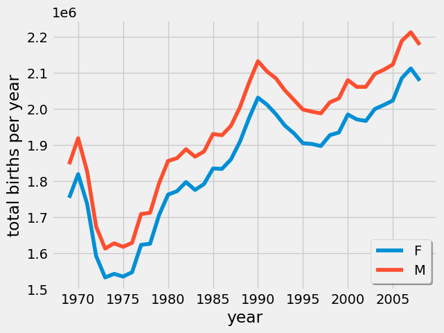

```python
births.pivot_table(values='births',index='year',\
                   columns='gender',aggfunc='sum').plot()
plt.ylabel('total births per year')
plt.legend(loc='lower right',fancybox=True,shadow=True)
```

图 3-2：各年不同性别出生人数分布图

深入探索  
虽然使用数据透视表并不是必须的，但是通过 Pandas 的这个工具可以 展现一些有趣的特征。我们必须对数据做一点儿清理工作，消除由于输  
错了日期而造成的异常点（如 6 月 31 号）或者是缺失值（如 1999 年 6  
月）。消除这些异常的简便方法就是直接删除异常值，可以通过更稳定  
的 sigma 消除法（sigma-clipping，按照正态分布标准差划定范围，  
SciPy 中默认是四个标准差）操作来实现：

```python
quartiles = np.percentile(births['births'], [25, 50, 75])
mu = quartiles[1]
sig = 0.74 * (quartiles[2] - quartiles[0])
```

```python
births = births.query('(births > @mu - 5 * @sig) & (births < @mu + 5 * @sig)')
```

```python
# 将'day'列设置为整数。由于其中含有缺失值null，因此是字符串
births['day'] = births['day'].astype(int)
```

现在就可以将年月日组合起来创建一个日期索引了（详情请参见 3.12 节），这样就可以快速计算每一行是星期几：

```python
 # 从年月日创建一个日期索引
births.index = pd.to_datetime(10000 * births.year +
100 * births.month +
births.day, format='%Y%m%d')
births['dayofweek'] = births.index.dayofweek
```

用这个索引可以画出不同年代不同星期的日均出生数据（如图 3-3 所 示）：

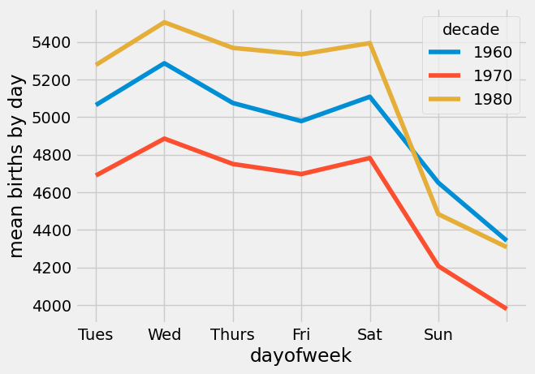

```python
births.pivot_table('births', index='dayofweek',
            columns='decade', aggfunc='mean').plot()
plt.gca().set_xticklabels(['Mon', 'Tues', 'Wed', 'Thurs',\
                           'Fri', 'Sat', 'Sun'])
plt.ylabel('mean births by day');
```

图 3-3：不同年代不同星期的日均出生数据

```python
births_by_date = births.pivot_table('births',
[births.index.month, births.index.day])
births_by_date.head()
```

|  |  | births |
| --- | --- | --- |
| 1 | 1 | 4009.225 |
|  | 2 | 4247.400 |
|  | 3 | 4500.900 |
|  | 4 | 4571.350 |
|  | 5 | 4603.625 |

这是一个包含月和日的多级索引。为了让数据可以用图形表示，我们可 以虚构一个年份，与月和日组合成新索引（注意日期为 2 月 29 日时， 索引年份需要用闰年，例如 2012）：

```python
births_by_date.index
```

```
MultiIndex([( 1,  1),
            ( 1,  2),
            ( 1,  3),
            ( 1,  4),
            ( 1,  5),
            ( 1,  6),
            ( 1,  7),
            ( 1,  8),
            ( 1,  9),
            ( 1, 10),
            ...
            (12, 22),
            (12, 23),
            (12, 24),
            (12, 25),
            (12, 26),
            (12, 27),
            (12, 28),
            (12, 29),
            (12, 30),
            (12, 31)],
           length=366)
```

```python
births_by_date.index = pd.to_datetime(['2012-{}-{}'.format(month, day) for (month, day) in births_by_date.index])
births_by_date.head()
```

|  | births |
| --- | --- |
| 2012-01-01 | 4009.225 |
| 2012-01-02 | 4247.400 |
| 2012-01-03 | 4500.900 |
| 2012-01-04 | 4571.350 |
| 2012-01-05 | 4603.625 |

如果只关心月和日的话，这就是一个可以反映一年中平均每天出生人数 的时间序列。可以用 plot 方法将数据画成图（如图 3-4 所示），从图 中可以看到一些有趣的趋势：

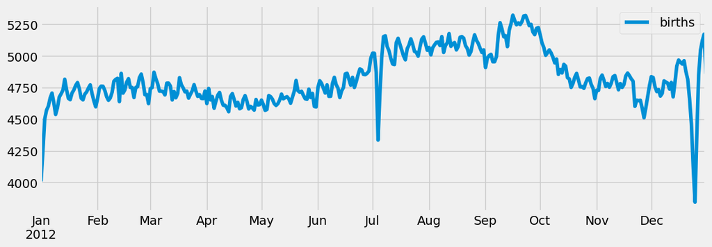

```python
fig, ax = plt.subplots(figsize=(12, 4))
births_by_date.plot(ax=ax);
```

图 3-4：平均每天的出生人数

从图中可以明显看出，在美国节假日的时候，出生人数急速下降（例如 美国独立日、劳动节、感恩节、圣诞节以及新年）。这种现象可能是由 于医院放假导致的接生减少（自己在家生），而非某种自然生育的心理 学效应。关于这个趋势的更详细介绍，请参考 Andrew Gelman 的博客 （[http://bit.ly/2fZzW8K）。我们将在](http://bit.ly/2fZzW8K%EF%BC%89%E3%80%82%E6%88%91%E4%BB%AC%E5%B0%86%E5%9C%A8) 4.11.1 节再次使用这张图，那时将 用 Matplotlib 的画图工具为这张图增加标注。 通过这个简单的案例，你会发现许多前面介绍过的 Python 和 Pandas 工 具都可以相互结合，并用于从大量数据集中获取信息。我们将在后面的 章节中介绍如何用这些工具创建更复杂的应用。